# An Illustrative Look

Marshall McQuillen

## Guiding question

Which passengers will survive the sinking of the Titanic?

## Secondary Questions

1. What characteristics separate those who survived from those who died?
2. What charactersistics make someone more likely to survive?
3. What combination of characteristics leads to the best prediction of whether someone will survive?

```r
setwd("/Users/marsh/data_science_projects/kaggle_titanic_ml/")
training <- read.csv('/Users/marsh/data_science_projects/kaggle_titanic_ml/titanic_train.csv')
testing <- read.csv("/Users/marsh/data_science_projects/kaggle_titanic_ml//titanic_test.csv")
```

```r
suppressPackageStartupMessages(library(ggplot2))
suppressPackageStartupMessages(library(dplyr))
suppressPackageStartupMessages(library(plotly))
```

## Data Cleaning

All the NA’s in the data set are in the Age column. The column is close to 20% NA’s so building a model on that variable won’t be the best idea.

```r
#Set classes
str(training)
```

```
## 'data.frame':    891 obs. of  12 variables:
##  $ PassengerId: int  1 2 3 4 5 6 7 8 9 10 ...
##  $ Survived   : int  0 1 1 1 0 0 0 0 1 1 ...
##  $ Pclass     : int  3 1 3 1 3 3 1 3 3 2 ...
##  $ Name       : Factor w/ 891 levels "Abbing, Mr. Anthony",..: 109 191 358 277 16 559 520 629 417 581 ...
##  $ Sex        : Factor w/ 2 levels "female","male": 2 1 1 1 2 2 2 2 1 1 ...
##  $ Age        : num  22 38 26 35 35 NA 54 2 27 14 ...
##  $ SibSp      : int  1 1 0 1 0 0 0 3 0 1 ...
##  $ Parch      : int  0 0 0 0 0 0 0 1 2 0 ...
##  $ Ticket     : Factor w/ 681 levels "110152","110413",..: 524 597 670 50 473 276 86 396 345 133 ...
##  $ Fare       : num  7.25 71.28 7.92 53.1 8.05 ...
##  $ Cabin      : Factor w/ 148 levels "","A10","A14",..: 1 83 1 57 1 1 131 1 1 1 ...
##  $ Embarked   : Factor w/ 4 levels "","C","Q","S": 4 2 4 4 4 3 4 4 4 2 ...
```

```r
training$PassengerId <- as.factor(training$PassengerId)
training$Survived <- as.factor(training$Survived)
training$Pclass <- as.factor(training$Pclass)
training$SibSp <- as.factor(training$SibSp)
training$Parch <- as.factor(training$Parch)

#View where NA's are in realtion to columns
NAs <- lapply(training[,1:12], is.na)
lapply(NAs, sum)
```

```
## $PassengerId
## [1] 0
##
## $Survived
## [1] 0
##
## $Pclass
## [1] 0
##
## $Name
## [1] 0
##
## $Sex
## [1] 0
##
## $Age
## [1] 177
##
## $SibSp
## [1] 0
##
## $Parch
## [1] 0
##
## $Ticket
## [1] 0
##
## $Fare
## [1] 0
##
## $Cabin
## [1] 0
##
## $Embarked
## [1] 0
```

```r
#Percent of Age attribute that is NA
paste(round(sum(is.na(training$Age))/length(training$Age)*100, digits = 2), "%", sep = "")
```

```
## [1] "19.87%"
```

## 2 Bayesian Survival

### 2.2 Does Money Sink or Swim?

#### Illustrating Bayes Theorem with Survival Rates and Socio-Economic Status

By creating a table with the Pclass and Survived variables, I can get a good sense of the number of passengers that lived and died, based on their Socio-Economic Status (SES). Simple summation and division returns the probabilites of a passenger living given their respective SES.

```r
#Probability of living by socio-economic status
pclass_table <- with(training, table(Survived, Pclass))
upper_class <- pclass_table[2,1]/sum(pclass_table[,1])*100
middle_class <- pclass_table[2,2]/sum(pclass_table[,2])*100
lower_class <- pclass_table[2,3]/sum(pclass_table[,3])*100

pclass_table
```

```
##         Pclass
## Survived   1   2   3
##        0  80  97 372
##        1 136  87 119
```

```r
#Probability of living given Upper Class
paste(round(upper_class, digits = 2), "%", sep = "")
```

```
## [1] "62.96%"
```

```r
#Probability of living given Middle Class
paste(round(middle_class, digits = 2), "%", sep = "")
```

```
## [1] "47.28%"
```

```r
#Probability of living given Lower Class
paste(round(lower_class, digits = 2), "%", sep = "")
```

```
## [1] "24.24%"
```

The same information can be displayed visually as follows.

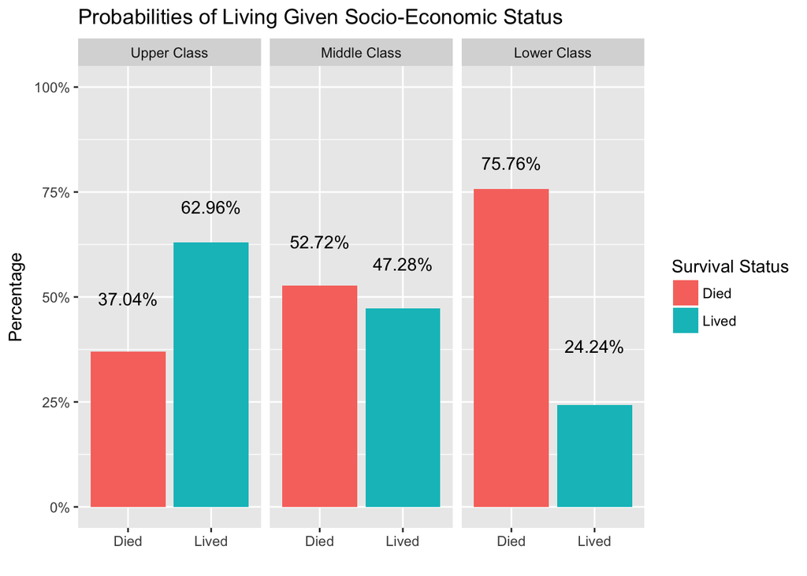

```r
g <- ggplot(training, aes(y=Survived,  x=factor(Survived,
                                                labels=c("Died","Lived"))))
g <- g + geom_bar(aes(y=..prop.., group=Pclass,
                      fill=factor(..x.., labels=c("Died","Lived"))))
g <- g + facet_grid(~factor(Pclass,
                            labels=c("Upper Class", "Middle Class",
                                     "Lower Class")))
g <- g + scale_y_continuous(labels = scales::percent)
g <- g + scale_fill_discrete(name="Survival Status")
g <- g + labs(x="", y = "Percentage",
              title = "Probabilities of Living Given Socio-Economic Status")
g <- g + geom_text(
      aes(label = paste(round((..count../c(216,216,184,184,491,491)), 4)*100, "%", sep = ""), y = ..prop..),  stat= "count",
      vjust = c(17.25,10,12.75,14.5,6.5,21))
g
```

For a simple proof of Bayes Theorem, defined as…

…I can set **P(A) = the probability of a passenger belonging to a defined SES (X)** and **P(B) = the probability of a passenger living**. I can now rewrite the previously defined Theorm using my definitions as:

```r
total <- nrow(training)
total_died <- nrow(subset(training, Survived == 0))
total_lived <- nrow(subset(training, Survived == 1))

#Probability of Living = P(B)
prob_lived <- total_lived/(total_died + total_lived)

#Probability of being Upper, Middle or Lower class = P(A)
upper_prob <- as.numeric(table(training$Pclass)[1])/total
middle_prob <- as.numeric(table(training$Pclass)[2])/total
lower_prob <- as.numeric(table(training$Pclass)[3])/total
```

Now that I have found both **P(“X class citizen”)** (objects upper_prob, middle_prob and lower_prob) and **P(“Lived”)** (object prob_lived), and I have **P(“Lived”|“X class ctiizen”)** (objects upper_class, middle_class and lower_class), I can solve for **P(“X class citizen”|“Lived”)**…

```r
#Probability of being an Upper class citizen given a passenger lived
prob_upper_given_lived <- (upper_class*upper_prob)/prob_lived

#Probability of being a Middle class citizen given a passenger lived
prob_middle_given_lived <- (middle_class*middle_prob)/prob_lived

#Probability of being a Lower class ctizen given a passenger lived
prob_lower_given_lived <- (lower_class*lower_prob)/prob_lived
```

The “shorthand” way of finding these probabilites can be accomplished by dividing the the number of X class passengers that lived by the total number of passengers that lived using the pclass_table.

```r
#"Shorthand" for calculating probability of being a X class citizen using pclass_table
upper_class_by_total <- pclass_table[2,1]/total_lived*100
middle_class_by_total <- pclass_table[2,2]/total_lived*100
lower_class_by_total <- pclass_table[2,3]/total_lived*100

#Showing that the probabilities using Bayes Theorem and pclass_table are equal
all.equal(upper_class_by_total, prob_upper_given_lived)
```

```
## [1] TRUE
```

```r
all.equal(middle_class_by_total, prob_middle_given_lived)
```

```
## [1] TRUE
```

```r
all.equal(lower_class_by_total, prob_lower_given_lived)
```

```
## [1] TRUE
```

A graphic illustrating said results.

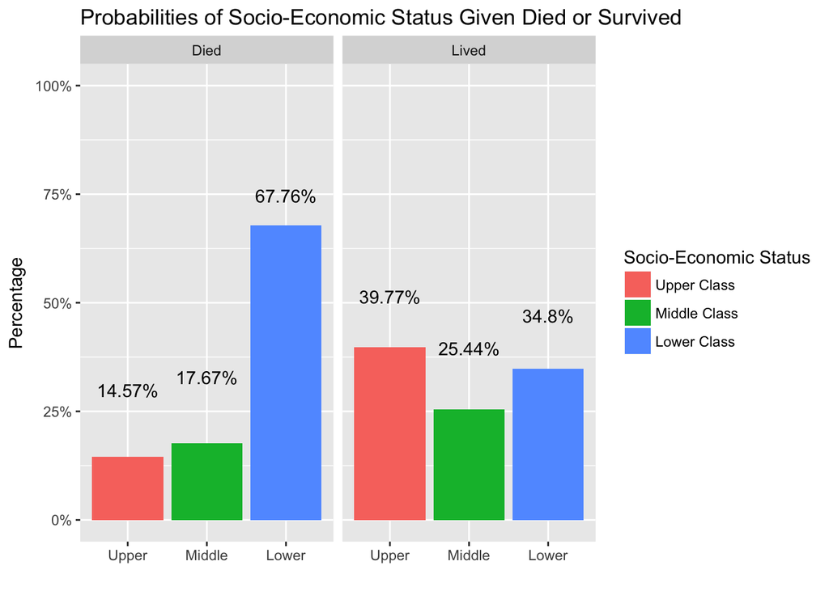

```r
f <- ggplot(training, aes(y = Pclass,
                          x = factor(Pclass,labels=c("Upper","Middle","Lower"))))
f <- f + geom_bar(aes(y=..prop.., group=Survived,
                      fill = factor(..x.., labels=c("Upper Class","Middle Class","Lower Class"))))
f <- f + facet_grid(~factor(Survived, labels = c("Died","Lived")))
f <- f + scale_y_continuous(labels = scales::percent)
f <- f + scale_fill_discrete(name = "Socio-Economic Status")
f <- f + labs(x = "", y = "Percentage", title = "Probabilities of Socio-Economic Status Given Died or Survived")
f <- f + geom_text(
      aes(label = paste(round((..count../c(549,549,549,342,342,342)), 4)*100, "%", sep = ""), y = ..prop..), stat= "count",
      vjust = c(24,23,9,16.75,20.75,18.25))
f
```

Using the same code as above, with a few minor adjustments I can make similar graphs with other qualitative variables, such as the sex of the passenger.

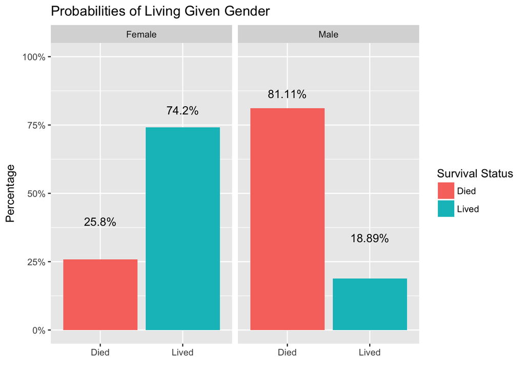

```r
#Sex vs. Survived
a <- ggplot(training, aes(y=Survived,  x=factor(Survived,
                                                labels=c("Died","Lived"))))
a <- a + geom_bar(aes(y=..prop.., group=Sex,
                      fill=factor(..x.., labels=c("Died","Lived"))))
a <- a + facet_grid(~factor(Sex,
                            labels=c("Female", "Male")))
a <- a + scale_y_continuous(labels = scales::percent)
a <- a + scale_fill_discrete(name="Survival Status")
a <- a + labs(x="", y = "Percentage",
              title = "Probabilities of Living Given Gender")
a <- a + geom_text(
      aes(label = paste(round((..count../c(314,314,577,577)), 4)*100, "%", sep = ""), y = ..prop..),  stat= "count",
      vjust = c(20.5,7,5,22.5))
a
```

## 3 Cabin Classification

```r
#Split data on Cabin Letter
a_class <- training[grep("A", training$Cabin),]
b_class <- training[grep("B", training$Cabin),]
c_class <- training[grep("C", training$Cabin),]
d_class <- training[grep("D", training$Cabin),]
e_class <- training[grep("E", training$Cabin),]
f_class <- training[grep("F", training$Cabin),]
g_class <- training[grep("G", training$Cabin),]
blank_class <- subset(training, Cabin == training[1,11])

sum(nrow(a_class) + nrow(b_class) + nrow(c_class) + nrow(d_class) +
          nrow(e_class) + nrow(f_class) + nrow(g_class) + nrow(blank_class))
```

```
## [1] 894
```

```r
#Duplicate Cabin Values
training[c(76,129,700,716),]
```

```
##     PassengerId Survived Pclass                                       Name
## 76           76        0      3                    Moen, Mr. Sigurd Hansen
## 129         129        1      3                          Peter, Miss. Anna
## 700         700        0      3   Humblen, Mr. Adolf Mathias Nicolai Olsen
## 716         716        0      3 Soholt, Mr. Peter Andreas Lauritz Andersen
##        Sex Age SibSp Parch Ticket    Fare Cabin Embarked
## 76    male  25     0     0 348123  7.6500 F G73        S
## 129 female  NA     1     1   2668 22.3583 F E69        C
## 700   male  42     0     0 348121  7.6500 F G63        S
## 716   male  19     0     0 348124  7.6500 F G73        S
```

```r
table(a_class$Survived)[2]/sum(table(a_class$Survived))
```

```
##         1
## 0.4666667
```

```r
table(b_class$Survived)[2]/sum(table(b_class$Survived))
```

```
##         1
## 0.7446809
```

```r
table(c_class$Survived)[2]/sum(table(c_class$Survived))
```

```
##         1
## 0.5932203
```

```r
table(d_class$Survived)[2]/sum(table(d_class$Survived))
```

```
##         1
## 0.7575758
```

```r
table(e_class$Survived)[2]/sum(table(e_class$Survived))
```

```
##         1
## 0.7575758
```

```r
table(f_class$Survived)[2]/sum(table(f_class$Survived))
```

```
##         1
## 0.6153846
```

```r
table(g_class$Survived)[2]/sum(table(g_class$Survived))
```

```
##         1
## 0.2857143
```

```r
table(blank_class$Survived)[2]/sum(table(blank_class$Survived))
```

```
##         1
## 0.2998544
```

```r
#Split data on Cabin Room Number
tCabin_number = grep("[0-9]{2,}", training$Cabin)
test <- mutate(training, test_column = c(strsplit(as.character(training$Cabin), " ")))

#Parch and Sibsp Analysis
table(training$Parch, training$Survived)
```

```
##
##       0   1
##   0 445 233
##   1  53  65
##   2  40  40
##   3   2   3
##   4   4   0
##   5   4   1
##   6   1   0
```

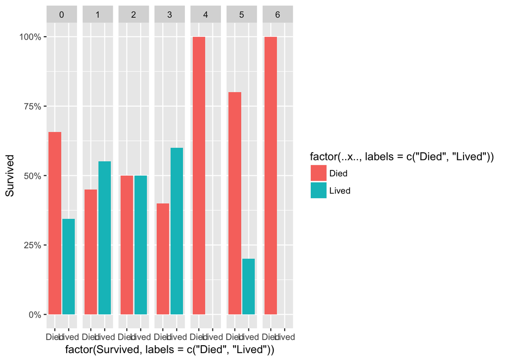

```r
h <- ggplot(data = training,
            aes(y = Survived,
                x = factor(Survived, labels = c("Died","Lived"))))
h <- h + geom_bar(aes(y = ..prop.., group = Parch,
                      fill = factor(..x.., labels = c("Died","Lived"))))
h <- h + facet_grid(~Parch)
h <- h + scale_y_continuous(labels = scales::percent)
h <- h + scale_fill_discrete()
h
```

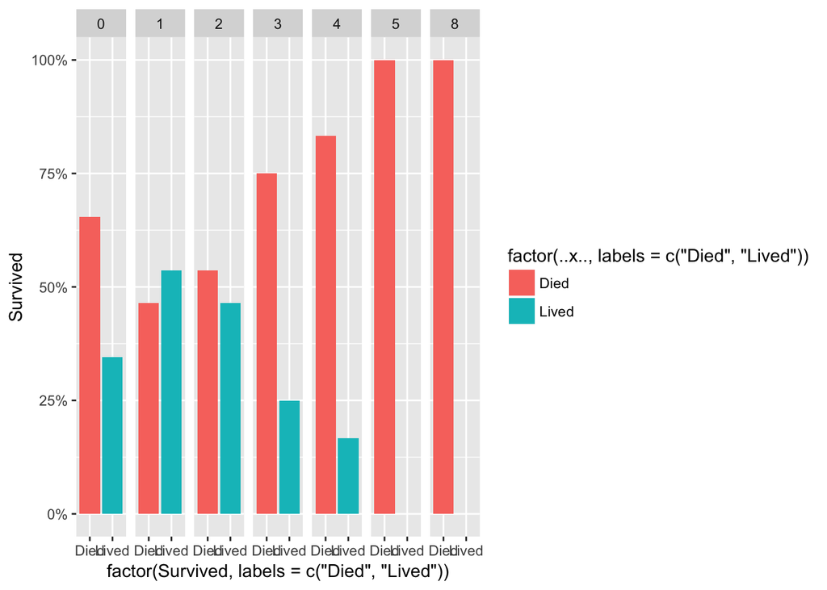

```r
d <- ggplot(data = training,
            aes(y = Survived,
                x = factor(Survived, labels = c("Died","Lived"))))
d <- d + geom_bar(aes(y = ..prop.., group = SibSp,
                      fill = factor(..x.., labels = c("Died","Lived"))))
d <- d + facet_grid(~SibSp)
d <- d + scale_y_continuous(labels = scales::percent)
d <- d + scale_fill_discrete()
d
```